# Spatial statistics

Kerstin Wiegand, Craig Simpkins, Maximilian Hesselbarth

Summer semester 2019

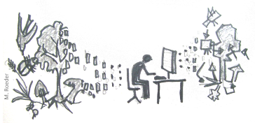

# Practical 2b

First, we load all needed packages, just as before.

```r
  library(spatstat)
  library(tidyverse)
```

## Exercise 5

**Task:** Calculate the bivariate g12 function using the null model random labeling. Was the process that labeled trees as dead or alive a random process.

In case it is not in our workspace anymore, we import the data and convert it to a `ppp` object again.

```r
  douglas_fir <- read_delim(file = "Data/DouglasFir_LiveDead_OGN.txt",
                            delim = ";")

  douglas_fir <- mutate(douglas_fir,
                        mark = case_when(mark == 1 ~ "alive",
                                         mark == 2 ~ "dead"),
                        mark = as.factor(mark))

  plot_area <- ripras(x = douglas_fir$x, y = douglas_fir$y,
                      shape = "rectangle")

  douglas_fir_ppp <- as.ppp(X = douglas_fir, W = plot_area)
```

The same goes for the O-ring statistic.

```r
  Oest <- function(input, r = NULL,
                   correction = "Ripley", divisor = "d", ...){

    p_fct <- pcf(input, r = r,
                 correction = correction, divisor = divisor, ...)

    lambda <- intensity(unmark(input))

    eval.fv(p_fct * lambda)
  }
```

The function `envelope()` can also be used to simulate more complex null models than ‘CSR’ and basically all functions (`fun`) that return a `fv` object. This time, we use the bivariate pair-correlation function as `fun` called `pcfcross` in `spatstat`. We need to specify the arguments of `pcfcross` `i` and `j` indicating the two types of marks. `simulate` allows us to specify any possible null model as an expression. Random labeling can be simulated with the help of `rlabel`. Lastly, we specify the number of simulation (`nsim`) and the highest/lowest values to use for the envelopes (`nrank`) and the distances at which the function should be evaluated (`r`) just as before.

```r
  random_labeling <- envelope(douglas_fir_ppp,
                              fun = pcfcross,
                              i = "alive",  j = "dead",
                              r = seq(from = 0, to = 45, by = 0.5),
                              divisor = "d", nsim = 199, nrank = 5,
                              simulate = expression(rlabel(douglas_fir_ppp)))
```

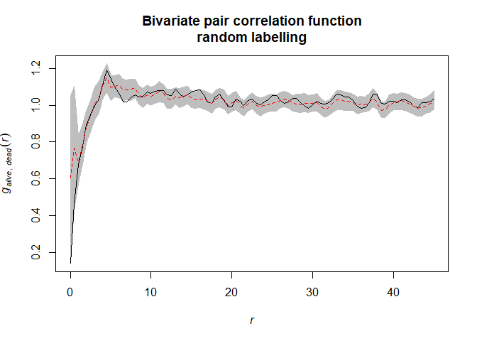

## Exercise 6

**Task:** Can the small-scale regularity in the live Douglas fir trees be modeled by a hard-core process? What about a soft-core process?

We can use `rStrauss()` to simulate hardcore- and softcore processes. Firstly, we subset the data using only living trees. Then, we simulate the hardcore process. We want the same intensity as the observed data (`beta`). `R` is the interaction distance between the points and `gamma` is the probability of two points being separated by distances < `R`. Therefore, setting this argument to 0 leads to a hardcore process. Lastly, we need to specify the number of (`nsim`) and the observation window (`W`, same as observed data) of the simulated patterns.

```r
  alive <- subset.ppp(douglas_fir_ppp, marks == "alive", drop = T)

  simulated_patterns_hardcore <- rStrauss(beta = intensity(alive),
                                          R = 1, gamma = 0,
                                          nsim = 199, W = alive$window)
```

The result is a list of simulated point patterns, that can be used as the `simulate` argument of the `envelope()` function. Now, the function calculates the summary function for each pattern in the list and computes the envelopes based on the results.

```r
  envelope_hardcore <- envelope(Y = alive, fun = Oest,
                                r = seq(from = 0, to = 45, by = 0.5),
                                nsim = 199, nrank = 5,
                                simulate = simulated_patterns_hardcore)
```

The softcore process is very similar, with the only difference that the probability `gamma` of two points being separated by distance `R` is increased.

```r
  simulated_patterns_softcore <- rStrauss(beta = intensity(alive),
                                          R = 1, gamma = 0.3,
                                          nsim = 199, W = alive$window)

  envelope_softcore <- envelope(alive, fun = Oest,
                                r = seq(from = 0, to = 45, by = 0.5),
                                nsim = 199, nrank = 5,
                                simulate = simulated_patterns_softcore)
```

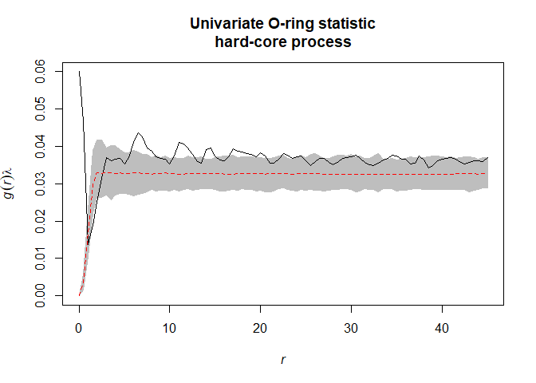

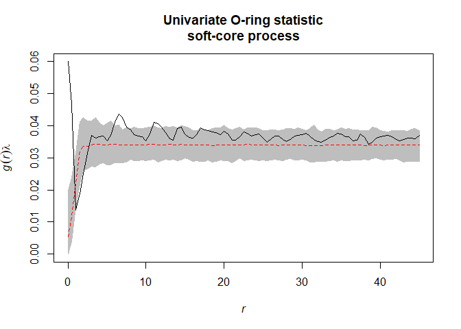

## Exercise 7

**Task:** Now use the data set *DouglasFir_Adult_vs_Seedling_OGN.txt*. Here, pattern 1 gives the locations of adult trees and pattern 2 gives the locations of seedlings. Calculate O12(r) and generate 95% confidence envelopes for the null model ‘Pattern 1 fixed, pattern 2 random’ (‘antecedent conditions’). What would be a meaningful interpretation of the results?

Firstly, we import the data and convert it to a `ppp` object. Also, we reclassify the mark column to 1 == ‘adults’ and 2 == ‘seedlings’ and convert is as a factor.

```r
  douglas_fir <- read_delim(file = "Data/DouglasFir_Adult_vs_Seedling_OGN.txt",
                            delim = ";")
```

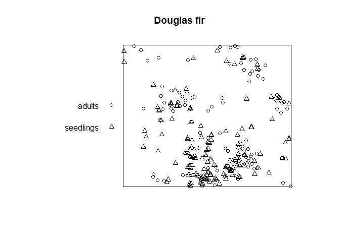

```r
  douglas_fir <- mutate(douglas_fir,
                        mark = case_when(mark == 1 ~ "adults",
                                         mark == 2 ~ "seedlings"),
                        mark = as.factor(mark))

  plot_area <- ripras(x = douglas_fir$x, y = douglas_fir$y,
                      shape = "rectangle")

  douglas_fir_ppp <- as.ppp(X = douglas_fir, W = plot_area)
```

Now, we need to implement the bivariate O-ring statistic O12(r). We want to multiply the bivariate pair-correlation function g12(r) with the intensity of lambda2.

```r
Oest_cross <- function(input, i, j, r = NULL,
                       correction = "Ripley", divisor = "d", ...){

  gij <- pcfcross(input,
                  i = i, j = j, r = r,
                  correction = correction, divisor = divisor, ...)

  lambda <- intensity(input)[j]

  eval.fv(gij * lambda)
}
```

`spatstat` has no build-in function to simulate a null model of ‘antecedent conditions’. But remember, we can give the `simulate` argument of the `envelope()` function a list of patterns. Therefore, we just need to simulate the null model and save the results in a list.

After splitting the point pattern into seedlings and adults, we create a new, random pattern with the same number of points (`n`) and the same observation window (`win`) as the seedlings. Then, we superimpose the random seedlings with the unchanged adults. Lastly, we save the result in a list.

```r
null_model_pattern <- list()

for(i in 1:199){
  seedlings <- subset.ppp(douglas_fir_ppp,
                          marks == "seedlings", drop = TRUE)

  adults <- subset.ppp(douglas_fir_ppp, marks == "adults", drop = TRUE)

  random_seedlings <- rpoint(n = seedlings$n,
                             win = seedlings$window)

  overall_pattern <- superimpose(adults = unmark(adults),
                                 seedlings = random_seedlings)

  null_model_pattern[i] <- list(overall_pattern)
}
```

Now, we can compute the simulation envelopes as usually.

```r
  antecedent_conditions <- envelope(douglas_fir_ppp,
                                    fun = Oest_cross,
                                    i = "adults", j = "seedlings",
                                    r = seq(from = 0, to = 45,
                                            by = 0.5),
                                    nsim = 199,  nrank = 5,
                                    simulate = null_model_pattern)
```

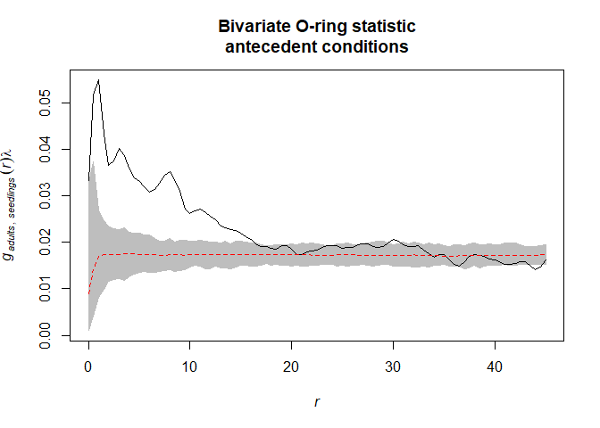

The [`onpoint`](https://r-spatialecology.github.io/onpoint/) package also includes an function to simulate antecedent conditions as null model (see `?simulate_antecedent_conditions` for help).

## Exercise 8

**Task:** How does the interpretation of the ‘Toroidal shift’ null model differ from the null models in 7)? What is the advantage? Is it always an advantage?

There is a possibility to simulate the ‘toroidal shift’ null model with functions provided by `spatstat`. We just use the function `rshift()` and specify the behavior at the edge of the observation area (`edge`) and which points should be shifted (`which`).

```r
toroidal_shift <- envelope(douglas_fir_ppp, fun = Oest_cross,
                           i = "adults", j = "seedlings",
                           r = seq(from = 0, to = 45, by = 0.5),
                           nsim = 199, nrank = 5,
                           simulate = expression(rshift(douglas_fir_ppp,
                                                        which = "seedlings",
                                                        edge = "torus")))
```

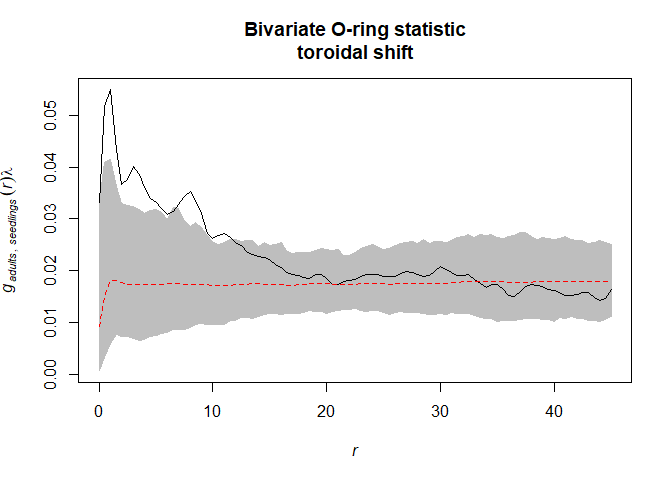

**References**:

Baddeley, A., Rubak, E., Turner, R., 2015. Spatial point patterns: Methodology and applications with R. Chapman and Hall/CRC Press, London.

Getzin, S., Dean, C., He, F., Trofymow, J.A., Wiegand, K., Wiegand, T., 2006. Spatial patterns and competition of tree species in a Douglas fir chronosequence on Vancouver Island. Ecography, 29, 671-682.

Getzin, S., Wiegand, T., Wiegand, K., He, F., 2008. Heterogeneity influences spatial patterns and demographics in forest stands. J. Ecol. 96, 807-820.